# **Problem Statement**

## Business Context

Renewable energy sources play an increasingly important role in the global energy mix, as the effort to reduce the environmental impact of energy production increases.

Out of all the renewable energy alternatives, wind energy is one of the most developed technologies worldwide. The U.S Department of Energy has put together a guide to achieving operational efficiency using predictive maintenance practices.

Predictive maintenance uses sensor information and analysis methods to measure and predict degradation and future component capability. The idea behind predictive maintenance is that failure patterns are predictable and if component failure can be predicted accurately and the component is replaced before it fails, the costs of operation and maintenance will be much lower.

The sensors fitted across different machines involved in the process of energy generation collect data related to various environmental factors (temperature, humidity, wind speed, etc.) and additional features related to various parts of the wind turbine (gearbox, tower, blades, break, etc.).

## Objective

“ReneWind” is a company working on improving the machinery/processes involved in the production of wind energy using machine learning and has collected data of generator failure of wind turbines using sensors. They have shared a ciphered version of the data, as the data collected through sensors is confidential (the type of data collected varies with companies). Data has 40 predictors, 20000 observations in the training set and 5000 in the test set.

The objective is to build various classification models, tune them, and find the best one that will help identify failures so that the generators could be repaired before failing/breaking to reduce the overall maintenance cost. The nature of predictions made by the classification model will translate as follows:

- True positives (TP) are failures correctly predicted by the model. These will result in repairing costs.
- False negatives (FN) are real failures where there is no detection by the model. These will result in replacement costs.
- False positives (FP) are detections where there is no failure. These will result in inspection costs.

It is given that the cost of repairing a generator is much less than the cost of replacing it, and the cost of inspection is less than the cost of repair.

“1” in the target variables should be considered as “failure” and “0” represents “No failure”.

## Data Description

The data provided is a transformed version of the original data which was collected using sensors.

- Train.csv - To be used for training and tuning of models.
- Test.csv - To be used only for testing the performance of the final best model.

Both the datasets consist of 40 predictor variables and 1 target variable.

# **Installing and Importing the necessary libraries**

```python
# Installing the libraries with the specified version
!pip install --no-deps tensorflow==2.18.0 scikit-learn==1.3.2 matplotlib===3.8.3 seaborn==0.13.2 numpy==1.26.4 pandas==2.2.2 -q --user --no-warn-script-location
```

```
     ━━━━━━━━━━━━━━━━━━━━━━━━━━━━━━━━━━━━━━━━ 61.0/61.0 kB 2.7 MB/s eta 0:00:00
   ━━━━━━━━━━━━━━━━━━━━━━━━━━━━━━━━━━━━━━━━ 615.5/615.5 MB 2.4 MB/s eta 0:00:00
   ━━━━━━━━━━━━━━━━━━━━━━━━━━━━━━━━━━━━━━━━ 10.8/10.8 MB 108.9 MB/s eta 0:00:00
   ━━━━━━━━━━━━━━━━━━━━━━━━━━━━━━━━━━━━━━━━ 11.6/11.6 MB 78.0 MB/s eta 0:00:00
   ━━━━━━━━━━━━━━━━━━━━━━━━━━━━━━━━━━━━━━━━ 18.0/18.0 MB 90.6 MB/s eta 0:00:00
```

**Note**:

- After running the above cell, kindly restart the runtime (for Google Colab) or notebook kernel (for Jupyter Notebook), and run all cells sequentially from the next cell.
- On executing the above line of code, you might see a warning regarding package dependencies. This error message can be ignored as the above code ensures that all necessary libraries and their dependencies are maintained to successfully execute the code in **this notebook**.

# **Loading the Data**

```python
# uncomment and run the following lines for Google Colab
from google.colab import drive
drive.mount('/content/drive')
```

```python
import pandas as pd  # Library for data manipulation and analysis.
import numpy as np   # Fundamental package for scientific computing.
import matplotlib.pyplot as plt  # Plotting library for creating visualizations.
import seaborn as sns #For advanced visualizations.

from sklearn.model_selection import train_test_split  # Function for splitting datasets for training and testing.

import time  # Module for time-related operations.

import tensorflow as tf #An end-to-end open source machine learning platform
from tensorflow import keras  # High-level neural networks API for deep learning.
from keras import backend   # Abstraction layer for neural network backend engines.
from keras.models import Sequential  # Model for building NN sequentially.
from keras.layers import Dense   # for creating fully connected neural network layers.
```

```python
# Set the seed using keras.utils.set_random_seed. This will set:
# 1) `numpy` seed
# 2) backend random seed
# 3) `python` random seed
keras.utils.set_random_seed(819)

# If using TensorFlow, this will make GPU ops as deterministic as possible,
# but it might affect the overall performance
tf.config.experimental.enable_op_determinism()
```

```python
# Load the training and testing data
train_df = pd.read_csv('/content/drive/MyDrive/Colab Notebooks/Neural Networks/Train.csv')
test_df = pd.read_csv('/content/drive/MyDrive/Colab Notebooks/Neural Networks/Test.csv')

# Display the first few rows of the training data
print("Training Data:")
display(train_df.head())

# Display the first few rows of the testing data
print("\nTesting Data:")
display(test_df.head())
```

```
Training Data:
```

|  | V1 | V2 | V3 | V4 | V5 | V6 | V7 | V8 | V9 | V10 | ... | V32 | V33 | V34 | V35 | V36 | V37 | V38 | V39 | V40 | Target |
| --- | --- | --- | --- | --- | --- | --- | --- | --- | --- | --- | --- | --- | --- | --- | --- | --- | --- | --- | --- | --- | --- |
| 0 | -4.464606 | -4.679129 | 3.101546 | 0.506130 | -0.221083 | -2.032511 | -2.910870 | 0.050714 | -1.522351 | 3.761892 | ... | 3.059700 | -1.690440 | 2.846296 | 2.235198 | 6.667486 | 0.443809 | -2.369169 | 2.950578 | -3.480324 | 0 |
| 1 | 3.365912 | 3.653381 | 0.909671 | -1.367528 | 0.332016 | 2.358938 | 0.732600 | -4.332135 | 0.565695 | -0.101080 | ... | -1.795474 | 3.032780 | -2.467514 | 1.894599 | -2.297780 | -1.731048 | 5.908837 | -0.386345 | 0.616242 | 0 |
| 2 | -3.831843 | -5.824444 | 0.634031 | -2.418815 | -1.773827 | 1.016824 | -2.098941 | -3.173204 | -2.081860 | 5.392621 | ... | -0.257101 | 0.803550 | 4.086219 | 2.292138 | 5.360850 | 0.351993 | 2.940021 | 3.839160 | -4.309402 | 0 |
| 3 | 1.618098 | 1.888342 | 7.046143 | -1.147285 | 0.083080 | -1.529780 | 0.207309 | -2.493629 | 0.344926 | 2.118578 | ... | -3.584425 | -2.577474 | 1.363769 | 0.622714 | 5.550100 | -1.526796 | 0.138853 | 3.101430 | -1.277378 | 0 |
| 4 | -0.111440 | 3.872488 | -3.758361 | -2.982897 | 3.792714 | 0.544960 | 0.205433 | 4.848994 | -1.854920 | -6.220023 | ... | 8.265896 | 6.629213 | -10.068689 | 1.222987 | -3.229763 | 1.686909 | -2.163896 | -3.644622 | 6.510338 | 0 |

5 rows × 41 columns

```
Testing Data:
```

|  | V1 | V2 | V3 | V4 | V5 | V6 | V7 | V8 | V9 | V10 | ... | V32 | V33 | V34 | V35 | V36 | V37 | V38 | V39 | V40 | Target |
| --- | --- | --- | --- | --- | --- | --- | --- | --- | --- | --- | --- | --- | --- | --- | --- | --- | --- | --- | --- | --- | --- |
| 0 | -0.613489 | -3.819640 | 2.202302 | 1.300420 | -1.184929 | -4.495964 | -1.835817 | 4.722989 | 1.206140 | -0.341909 | ... | 2.291204 | -5.411388 | 0.870073 | 0.574479 | 4.157191 | 1.428093 | -10.511342 | 0.454664 | -1.448363 | 0 |
| 1 | 0.389608 | -0.512341 | 0.527053 | -2.576776 | -1.016766 | 2.235112 | -0.441301 | -4.405744 | -0.332869 | 1.966794 | ... | -2.474936 | 2.493582 | 0.315165 | 2.059288 | 0.683859 | -0.485452 | 5.128350 | 1.720744 | -1.488235 | 0 |
| 2 | -0.874861 | -0.640632 | 4.084202 | -1.590454 | 0.525855 | -1.957592 | -0.695367 | 1.347309 | -1.732348 | 0.466500 | ... | -1.318888 | -2.997464 | 0.459664 | 0.619774 | 5.631504 | 1.323512 | -1.752154 | 1.808302 | 1.675748 | 0 |
| 3 | 0.238384 | 1.458607 | 4.014528 | 2.534478 | 1.196987 | -3.117330 | -0.924035 | 0.269493 | 1.322436 | 0.702345 | ... | 3.517918 | -3.074085 | -0.284220 | 0.954576 | 3.029331 | -1.367198 | -3.412140 | 0.906000 | -2.450889 | 0 |
| 4 | 5.828225 | 2.768260 | -1.234530 | 2.809264 | -1.641648 | -1.406698 | 0.568643 | 0.965043 | 1.918379 | -2.774855 | ... | 1.773841 | -1.501573 | -2.226702 | 4.776830 | -6.559698 | -0.805551 | -0.276007 | -3.858207 | -0.537694 | 0 |

5 rows × 41 columns

```python
# Separate features and target variable for training data
X = train_df.drop('Target', axis=1)
y = train_df['Target']

# Separate features and target variable for testing data
X_test = test_df.drop('Target', axis=1)
y_test = test_df['Target']

# Split the training data into training and validation sets
X_train, X_val, y_train, y_val = train_test_split(X, y, test_size=0.2, random_state=42, stratify=y)
```

# **Data Overview**

```python
# Print the shapes of the resulting datasets
print("Shape of X_train:", X_train.shape)
print("Shape of X_val:", X_val.shape)
print("Shape of y_train:", y_train.shape)
print("Shape of y_val:", y_val.shape)
print("Shape of X_test:", X_test.shape)
print("Shape of y_test:", y_test.shape)
```

```
Shape of X_train: (16000, 40)
Shape of X_val: (4000, 40)
Shape of y_train: (16000,)
Shape of y_val: (4000,)
Shape of X_test: (5000, 40)
Shape of y_test: (5000,)
```

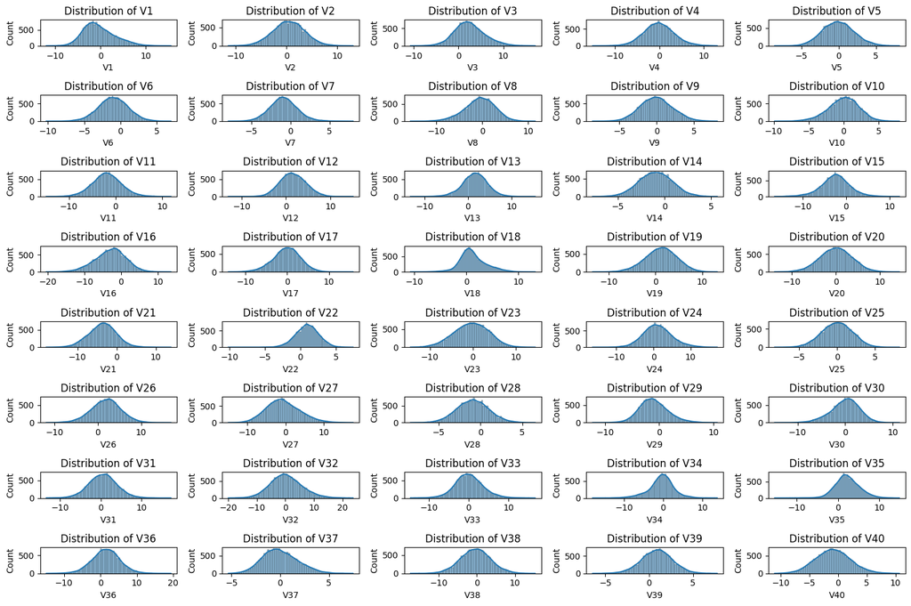

```python
# Visualize the distribution of a few features using histograms
features_to_visualize = [f'V{i}' for i in range(1, 41)] # Select all features from V1 to V40

plt.figure(figsize=(15, 10))
for i, feature in enumerate(features_to_visualize):
    plt.subplot(8, 5, i + 1) # Create an 8x5 grid of subplots
    sns.histplot(data=X_train, x=feature, kde=True)
    plt.title(f'Distribution of {feature}')
plt.tight_layout()
plt.show()
```

This bar plot shows the frequency of the target variable in the training dataset.

- The bar on the left represents observations with a target value of **0**, indicating "No Failure".
- The bar on the right represents observations with a target value of **1**, indicating "Failure".

As you can see, there are significantly more observations with "No Failure" (0) than "Failure" (1). This indicates that the dataset is **imbalanced**, which is an important consideration when building classification models. We need to be mindful of this imbalance and potentially use techniques to handle it during model training to ensure the model performs well on predicting the minority class ("Failure").

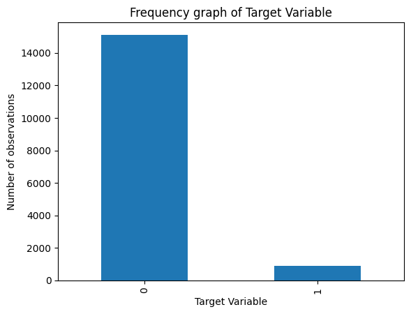

```python
# frequency plot of the dependent variable in the training dataset
(pd.Series(y_train).value_counts())[[0,1]].plot.bar()
plt.title("Frequency graph of Target Variable") #Setting the title
plt.xlabel("Target Variable") #Defining the label for the x-axis
plt.ylabel("Number of observations") #Defining the label for the y-axis.
plt.show() #Displaying the plot.
```

# **Exploratory Data Analysis**

```python
print("Training Data Info:")
train_df.info()

print("\nTesting Data Info:")
test_df.info()
```

```
Training Data Info:
<class 'pandas.core.frame.DataFrame'>
RangeIndex: 20000 entries, 0 to 19999
Data columns (total 41 columns):
 #   Column  Non-Null Count  Dtype
---  ------  --------------  -----
 0   V1      19982 non-null  float64
 1   V2      19982 non-null  float64
 2   V3      20000 non-null  float64
 3   V4      20000 non-null  float64
 4   V5      20000 non-null  float64
 5   V6      20000 non-null  float64
 6   V7      20000 non-null  float64
 7   V8      20000 non-null  float64
 8   V9      20000 non-null  float64
```

[output cut: 84 more lines]

## Univariate analysis

```python
# Display descriptive statistics for training data
print("Training Data Descriptive Statistics:")
display(train_df.describe())

# Check for missing values in training data
print("\nMissing values in Training Data:")
display(train_df.isnull().sum())

# Check for missing values in testing data
print("\nMissing values in Testing Data:")
display(test_df.isnull().sum())
```

```
Training Data Descriptive Statistics:
```

|  | V1 | V2 | V3 | V4 | V5 | V6 | V7 | V8 | V9 | V10 | ... | V32 | V33 | V34 | V35 | V36 | V37 | V38 | V39 | V40 | Target |
| --- | --- | --- | --- | --- | --- | --- | --- | --- | --- | --- | --- | --- | --- | --- | --- | --- | --- | --- | --- | --- | --- |
| count | 19982.000000 | 19982.000000 | 20000.000000 | 20000.000000 | 20000.000000 | 20000.000000 | 20000.000000 | 20000.000000 | 20000.000000 | 20000.000000 | ... | 20000.000000 | 20000.000000 | 20000.000000 | 20000.000000 | 20000.000000 | 20000.000000 | 20000.000000 | 20000.000000 | 20000.000000 | 20000.000000 |
| mean | -0.271996 | 0.440430 | 2.484699 | -0.083152 | -0.053752 | -0.995443 | -0.879325 | -0.548195 | -0.016808 | -0.012998 | ... | 0.303799 | 0.049825 | -0.462702 | 2.229620 | 1.514809 | 0.011316 | -0.344025 | 0.890653 | -0.875630 | 0.055500 |
| std | 3.441625 | 3.150784 | 3.388963 | 3.431595 | 2.104801 | 2.040970 | 1.761626 | 3.295756 | 2.160568 | 2.193201 | ... | 5.500400 | 3.575285 | 3.183841 | 2.937102 | 3.800860 | 1.788165 | 3.948147 | 1.753054 | 3.012155 | 0.228959 |
| min | -11.876451 | -12.319951 | -10.708139 | -15.082052 | -8.603361 | -10.227147 | -7.949681 | -15.657561 | -8.596313 | -9.853957 | ... | -19.876502 | -16.898353 | -17.985094 | -15.349803 | -14.833178 | -5.478350 | -17.375002 | -6.438880 | -11.023935 | 0.000000 |
| 25% | -2.737146 | -1.640674 | 0.206860 | -2.347660 | -1.535607 | -2.347238 | -2.030926 | -2.642665 | -1.494973 | -1.411212 | ... | -3.420469 | -2.242857 | -2.136984 | 0.336191 | -0.943809 | -1.255819 | -2.987638 | -0.272250 | -2.940193 | 0.000000 |
| 50% | -0.747917 | 0.471536 | 2.255786 | -0.135241 | -0.101952 | -1.000515 | -0.917179 | -0.389085 | -0.067597 | 0.100973 | ... | 0.052073 | -0.066249 | -0.255008 | 2.098633 | 1.566526 | -0.128435 | -0.316849 | 0.919261 | -0.920806 | 0.000000 |
| 75% | 1.840112 | 2.543967 | 4.566165 | 2.130615 | 1.340480 | 0.380330 | 0.223695 | 1.722965 | 1.409203 | 1.477045 | ... | 3.761722 | 2.255134 | 1.436935 | 4.064358 | 3.983939 | 1.175533 | 2.279399 | 2.057540 | 1.119897 | 0.000000 |
| max | 15.493002 | 13.089269 | 17.090919 | 13.236381 | 8.133797 | 6.975847 | 8.006091 | 11.679495 | 8.137580 | 8.108472 | ... | 23.633187 | 16.692486 | 14.358213 | 15.291065 | 19.329576 | 7.467006 | 15.289923 | 7.759877 | 10.654265 | 1.000000 |

8 rows × 41 columns

```
Missing values in Training Data:
```

|  | 0 |
| --- | --- |
| V1 | 18 |
| V2 | 18 |
| V3 | 0 |
| V4 | 0 |
| V5 | 0 |
| V6 | 0 |
| V7 | 0 |
| V8 | 0 |
| V9 | 0 |
| V10 | 0 |
| V11 | 0 |
| V12 | 0 |
| V13 | 0 |
| V14 | 0 |
| V15 | 0 |
| V16 | 0 |
| V17 | 0 |
| V18 | 0 |
| V19 | 0 |
| V20 | 0 |
| V21 | 0 |
| V22 | 0 |
| V23 | 0 |
| V24 | 0 |
| V25 | 0 |
| V26 | 0 |
| V27 | 0 |
| V28 | 0 |
| V29 | 0 |
| V30 | 0 |
| V31 | 0 |
| V32 | 0 |
| V33 | 0 |
| V34 | 0 |
| V35 | 0 |
| V36 | 0 |
| V37 | 0 |
| V38 | 0 |
| V39 | 0 |
| V40 | 0 |
| Target | 0 |

**dtype:** int64

```
Missing values in Testing Data:
```

|  | 0 |
| --- | --- |
| V1 | 5 |
| V2 | 6 |
| V3 | 0 |
| V4 | 0 |
| V5 | 0 |
| V6 | 0 |
| V7 | 0 |
| V8 | 0 |
| V9 | 0 |
| V10 | 0 |
| V11 | 0 |
| V12 | 0 |
| V13 | 0 |
| V14 | 0 |
| V15 | 0 |
| V16 | 0 |
| V17 | 0 |
| V18 | 0 |
| V19 | 0 |
| V20 | 0 |
| V21 | 0 |
| V22 | 0 |
| V23 | 0 |
| V24 | 0 |
| V25 | 0 |
| V26 | 0 |
| V27 | 0 |
| V28 | 0 |
| V29 | 0 |
| V30 | 0 |
| V31 | 0 |
| V32 | 0 |
| V33 | 0 |
| V34 | 0 |
| V35 | 0 |
| V36 | 0 |
| V37 | 0 |
| V38 | 0 |
| V39 | 0 |
| V40 | 0 |
| Target | 0 |

**dtype:** int64

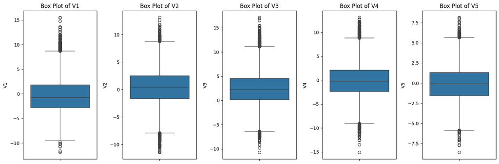

```python
# Visualize the distribution of a few features using box plots
features_to_visualize_box = ['V1', 'V2', 'V3', 'V4', 'V5'] # Select a few features to visualize

plt.figure(figsize=(15, 5))
for i, feature in enumerate(features_to_visualize_box):
    plt.subplot(1, 5, i + 1) # Create a 1x5 grid of subplots
    sns.boxplot(data=X_train, y=feature)
    plt.title(f'Box Plot of {feature}')
plt.tight_layout()
plt.show()
```

## Bivariate Analysis

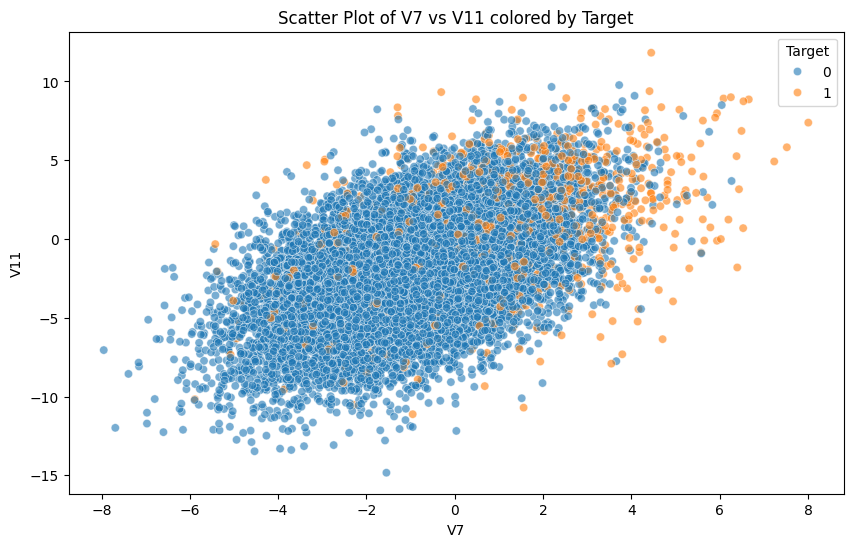

```python
# Visualize the relationship between two features, colored by the target variable
plt.figure(figsize=(10, 6))
sns.scatterplot(data=train_df, x='V7', y='V11', hue='Target', alpha=0.6)
plt.title('Scatter Plot of V7 vs V11 colored by Target')
plt.xlabel('V7')
plt.ylabel('V11')
plt.show()
```

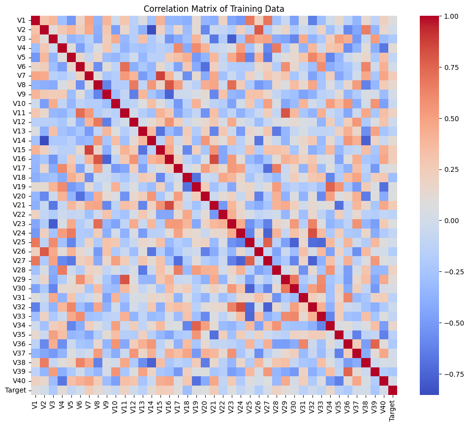

```python
# Calculate the correlation matrix
correlation_matrix = train_df.corr()

# Plot the correlation matrix as a heatmap
plt.figure(figsize=(12, 10))
sns.heatmap(correlation_matrix, cmap='coolwarm', fmt=".2f")
plt.title('Correlation Matrix of Training Data')
plt.show()
```

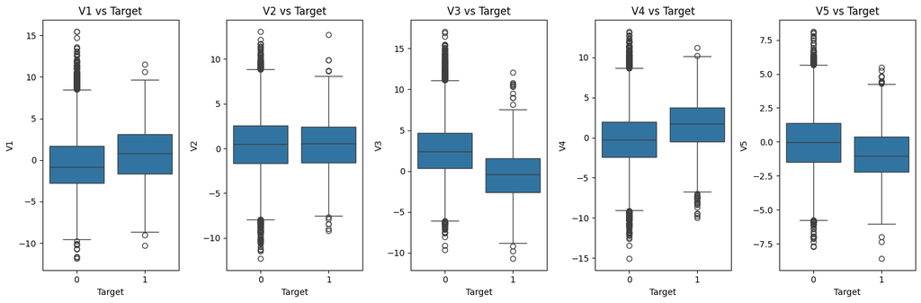

```python
# Visualize the relationship between a few features and the target variable using box plots
features_to_visualize_bivariate = ['V1', 'V2', 'V3', 'V4', 'V5'] # Select a few features to visualize

plt.figure(figsize=(15, 5))
for i, feature in enumerate(features_to_visualize_bivariate):
    plt.subplot(1, 5, i + 1) # Create a 1x5 grid of subplots
    sns.boxplot(data=train_df, x='Target', y=feature)
    plt.title(f'{feature} vs Target')
plt.tight_layout()
plt.show()
```

# **Data Preprocessing**

```python
# Impute missing values in 'V1' and 'V2' using the mean of the training data
X_train['V1'].fillna(X_train['V1'].mean(), inplace=True)
X_val['V1'].fillna(X_train['V1'].mean(), inplace=True)
X_test['V1'].fillna(X_train['V1'].mean(), inplace=True)

X_train['V2'].fillna(X_train['V2'].mean(), inplace=True)
X_val['V2'].fillna(X_train['V2'].mean(), inplace=True)
X_test['V2'].fillna(X_train['V2'].mean(), inplace=True)

# Verify that there are no more missing values in the 'V1' and 'V2' columns
print("Missing values in X_train after imputation:")
display(X_train[['V1', 'V2']].isnull().sum())

print("\nMissing values in X_val after imputation:")
display(X_val[['V1', 'V2']].isnull().sum())

print("\nMissing values in X_test after imputation:")
display(X_test[['V1', 'V2']].isnull().sum())
```

```
Missing values in X_train after imputation:
```

[output not shown]

|  | 0 |
| --- | --- |
| V1 | 0 |
| V2 | 0 |

**dtype:** int64

```
Missing values in X_val after imputation:
```

|  | 0 |
| --- | --- |
| V1 | 0 |
| V2 | 0 |

**dtype:** int64

```
Missing values in X_test after imputation:
```

|  | 0 |
| --- | --- |
| V1 | 0 |
| V2 | 0 |

**dtype:** int64

```python
from sklearn.preprocessing import StandardScaler

# Initialize the StandardScaler
scaler = StandardScaler()

# Fit the scaler on the training data and transform it
X_train_scaled = scaler.fit_transform(X_train)

# Transform the validation and test data using the scaler fitted on the training data
X_val_scaled = scaler.transform(X_val)
X_test_scaled = scaler.transform(X_test)

print("Shapes of scaled data:")
print("X_train_scaled:", X_train_scaled.shape)
print("X_val_scaled:", X_val_scaled.shape)
print("X_test_scaled:", X_test_scaled.shape)
```

```
Shapes of scaled data:
X_train_scaled: (16000, 40)
X_val_scaled: (4000, 40)
X_test_scaled: (5000, 40)
```

I decided to use StandardScaler instead of normalizing the data like shown in the practice coding files from the class videos since StandardScaler standardizes the data by removing the mean and scaling to unit variance. From my understanding, while "normalization" can sometimes refer to scaling features to a specific range (like between 0 and 1), "standardization" (what StandardScaler does) scales features to have a mean of 0 and a standard deviation of 1. For this project, I believe standardization is a stronger form of datas scaling since it is generally robust to outliers.

# **Model Building**

## Model Evaluation Criterion

Write down the model evaluation criterion with rationale

Based on the problem statement and the imbalanced nature of the target variable, a suitable model evaluation criterion would be **Recall** (also known as Sensitivity).

**Rationale:**

Since the cost of replacing a generator (due to a False Negative) is significantly higher than the cost of repairing a generator (True Positive) or inspecting a non-failed generator (False Positive), minimizing False Negatives is crucial.

Recall is defined as the ratio of True Positives to the sum of True Positives and False Negatives:

$$ \text{Recall} = \frac{\text{True Positives}}{\text{True Positives} + \text{False Negatives}} $$

Maximizing Recall directly aims to reduce the number of False Negatives, thereby minimizing the most costly error for ReneWind. While other metrics like Precision and F1-score are also important for evaluating classification models, Recall is the most aligned with the business objective of minimizing the financial impact of missed generator failures in this specific scenario.

## Initial Model Building (Model 0)

- Let's start with a neural network consisting of
  - just one hidden layer
  - activation function of ReLU
  - SGD as the optimizer

```python
from tensorflow.keras.optimizers import SGD
from tensorflow.keras.layers import Input # Import Input layer

# Define Model 0
model_0 = Sequential([
    Input(shape=(X_train_scaled.shape[1],)), # Use Input layer as the first layer
    Dense(64, activation='relu'), # One hidden layer with 64 units and ReLU activation
    Dense(1, activation='sigmoid') # Output layer with 1 unit for binary classification and sigmoid activation
])

# Compile the model
model_0.compile(optimizer=SGD(), # Stochastic Gradient Descent optimizer
                loss='binary_crossentropy', # Loss function for binary classification
                metrics=['Recall']) # Metric to optimize for

# Print the model summary
model_0.summary()
```

```
Model: "sequential_2"
```

```
┏━━━━━━━━━━━━━━━━━━━━━━━━━━━━━━━━━┳━━━━━━━━━━━━━━━━━━━━━━━━┳━━━━━━━━━━━━━━━┓
┃ Layer (type)                    ┃ Output Shape           ┃       Param # ┃
┡━━━━━━━━━━━━━━━━━━━━━━━━━━━━━━━━━╇━━━━━━━━━━━━━━━━━━━━━━━━╇━━━━━━━━━━━━━━━┩
│ dense_4 (Dense)                 │ (None, 64)             │         2,624 │
├─────────────────────────────────┼────────────────────────┼───────────────┤
│ dense_5 (Dense)                 │ (None, 1)              │            65 │
└─────────────────────────────────┴────────────────────────┴───────────────┘
```

```
 Total params: 2,689 (10.50 KB)
```

```
 Trainable params: 2,689 (10.50 KB)
```

```
 Non-trainable params: 0 (0.00 B)
```

```python
# Train Model 0
history_0 = model_0.fit(X_train_scaled, y_train,
                        epochs=10, # You can adjust the number of epochs
                        batch_size=32, # You can adjust the batch size
                        validation_data=(X_val_scaled, y_val))

# Evaluate Model 0 on the validation data
loss_0, recall_0 = model_0.evaluate(X_val_scaled, y_val)

print(f"\nValidation Loss for Model 0: {loss_0:.4f}")
print(f"Validation Recall for Model 0: {recall_0:.4f}")
```

```
500/500 ━━━━━━━━━━━━━━━━━━━━ 2s 3ms/step - Recall: 0.0868 - loss: 0.3521 - val_Recall: 0.1036 - val_loss: 0.1733
500/500 ━━━━━━━━━━━━━━━━━━━━ 2s 3ms/step - Recall: 0.2054 - loss: 0.1613 - val_Recall: 0.3333 - val_loss: 0.1390
500/500 ━━━━━━━━━━━━━━━━━━━━ 2s 3ms/step - Recall: 0.3759 - loss: 0.1333 - val_Recall: 0.4324 - val_loss: 0.1222
500/500 ━━━━━━━━━━━━━━━━━━━━ 2s 3ms/step - Recall: 0.4742 - loss: 0.1189 - val_Recall: 0.4685 - val_loss: 0.1115
500/500 ━━━━━━━━━━━━━━━━━━━━ 1s 2ms/step - Recall: 0.5361 - loss: 0.1093 - val_Recall: 0.5225 - val_loss: 0.1038
500/500 ━━━━━━━━━━━━━━━━━━━━ 1s 2ms/step - Recall: 0.5685 - loss: 0.1022 - val_Recall: 0.5721 - val_loss: 0.0979
500/500 ━━━━━━━━━━━━━━━━━━━━ 1s 2ms/step - Recall: 0.6042 - loss: 0.0965 - val_Recall: 0.6216 - val_loss: 0.0931
500/500 ━━━━━━━━━━━━━━━━━━━━ 1s 2ms/step - Recall: 0.6217 - loss: 0.0918 - val_Recall: 0.6486 - val_loss: 0.0892
500/500 ━━━━━━━━━━━━━━━━━━━━ 1s 2ms/step - Recall: 0.6459 - loss: 0.0877 - val_Recall: 0.6577 - val_loss: 0.0859
500/500 ━━━━━━━━━━━━━━━━━━━━ 1s 2ms/step - Recall: 0.6635 - loss: 0.0843 - val_Recall: 0.6757 - val_loss: 0.0830
125/125 ━━━━━━━━━━━━━━━━━━━━ 0s 2ms/step - Recall: 0.7115 - loss: 0.0771

Validation Loss for Model 0: 0.0830
Validation Recall for Model 0: 0.6757
```

# **Model Performance Improvement**

## Model 1

```python
# Define Model 1
model_1 = Sequential([
    Input(shape=(X_train_scaled.shape[1],)),
    Dense(64, activation='relu'), # First hidden layer
    Dense(32, activation='relu'), # Second hidden layer
    Dense(1, activation='sigmoid') # Output layer
])

# Compile the model
model_1.compile(optimizer=SGD(),
                loss='binary_crossentropy',
                metrics=['Recall'])

# Print the model summary
model_1.summary()

# Train Model 1
history_1 = model_1.fit(X_train_scaled, y_train,
                        epochs=10, # You can adjust the number of epochs
                        batch_size=32, # You can adjust the batch size
                        validation_data=(X_val_scaled, y_val))

# Evaluate Model 1 on the validation data
loss_1, recall_1 = model_1.evaluate(X_val_scaled, y_val)

print(f"\nValidation Loss for Model 1: {loss_1:.4f}")
print(f"Validation Recall for Model 1: {recall_1:.4f}")
```

```
Model: "sequential_3"
```

```
┏━━━━━━━━━━━━━━━━━━━━━━━━━━━━━━━━━┳━━━━━━━━━━━━━━━━━━━━━━━━┳━━━━━━━━━━━━━━━┓
┃ Layer (type)                    ┃ Output Shape           ┃       Param # ┃
┡━━━━━━━━━━━━━━━━━━━━━━━━━━━━━━━━━╇━━━━━━━━━━━━━━━━━━━━━━━━╇━━━━━━━━━━━━━━━┩
│ dense_6 (Dense)                 │ (None, 64)             │         2,624 │
├─────────────────────────────────┼────────────────────────┼───────────────┤
│ dense_7 (Dense)                 │ (None, 32)             │         2,080 │
├─────────────────────────────────┼────────────────────────┼───────────────┤
│ dense_8 (Dense)                 │ (None, 1)              │            33 │
└─────────────────────────────────┴────────────────────────┴───────────────┘
```

```
 Total params: 4,737 (18.50 KB)
```

```
 Trainable params: 4,737 (18.50 KB)
```

```
 Non-trainable params: 0 (0.00 B)
```

```
500/500 ━━━━━━━━━━━━━━━━━━━━ 2s 3ms/step - Recall: 0.0822 - loss: 0.2995 - val_Recall: 0.0901 - val_loss: 0.1623
500/500 ━━━━━━━━━━━━━━━━━━━━ 1s 2ms/step - Recall: 0.2161 - loss: 0.1450 - val_Recall: 0.3559 - val_loss: 0.1253
500/500 ━━━━━━━━━━━━━━━━━━━━ 2s 3ms/step - Recall: 0.4723 - loss: 0.1147 - val_Recall: 0.5045 - val_loss: 0.1059
500/500 ━━━━━━━━━━━━━━━━━━━━ 2s 3ms/step - Recall: 0.5847 - loss: 0.0988 - val_Recall: 0.5946 - val_loss: 0.0936
500/500 ━━━━━━━━━━━━━━━━━━━━ 2s 3ms/step - Recall: 0.6504 - loss: 0.0885 - val_Recall: 0.6441 - val_loss: 0.0852
500/500 ━━━━━━━━━━━━━━━━━━━━ 1s 2ms/step - Recall: 0.6953 - loss: 0.0812 - val_Recall: 0.6937 - val_loss: 0.0790
500/500 ━━━━━━━━━━━━━━━━━━━━ 1s 2ms/step - Recall: 0.7124 - loss: 0.0759 - val_Recall: 0.7207 - val_loss: 0.0744
500/500 ━━━━━━━━━━━━━━━━━━━━ 1s 2ms/step - Recall: 0.7327 - loss: 0.0717 - val_Recall: 0.7477 - val_loss: 0.0707
500/500 ━━━━━━━━━━━━━━━━━━━━ 1s 2ms/step - Recall: 0.7587 - loss: 0.0685 - val_Recall: 0.7613 - val_loss: 0.0678
500/500 ━━━━━━━━━━━━━━━━━━━━ 1s 2ms/step - Recall: 0.7730 - loss: 0.0659 - val_Recall: 0.7838 - val_loss: 0.0654
125/125 ━━━━━━━━━━━━━━━━━━━━ 0s 2ms/step - Recall: 0.8008 - loss: 0.0616

Validation Loss for Model 1: 0.0654
Validation Recall for Model 1: 0.7838
```

## Model 2

```python
from tensorflow.keras.optimizers import Adam

# Define Model 2
model_2 = Sequential([
    Input(shape=(X_train_scaled.shape[1],)),
    Dense(64, activation='relu'), # First hidden layer
    Dense(32, activation='relu'), # Second hidden layer
    Dense(1, activation='sigmoid') # Output layer
])

# Compile the model
model_2.compile(optimizer=Adam(), # Adam optimizer
                loss='binary_crossentropy',
                metrics=['Recall'])

# Print the model summary
model_2.summary()

# Train Model 2
history_2 = model_2.fit(X_train_scaled, y_train,
                        epochs=10, # You can adjust the number of epochs
                        batch_size=32, # You can adjust the batch size
                        validation_data=(X_val_scaled, y_val))

# Evaluate Model 2 on the validation data
loss_2, recall_2 = model_2.evaluate(X_val_scaled, y_val)

print(f"\nValidation Loss for Model 2: {loss_2:.4f}")
print(f"Validation Recall for Model 2: {recall_2:.4f}")
```

```
Model: "sequential_4"
```

```
┏━━━━━━━━━━━━━━━━━━━━━━━━━━━━━━━━━┳━━━━━━━━━━━━━━━━━━━━━━━━┳━━━━━━━━━━━━━━━┓
┃ Layer (type)                    ┃ Output Shape           ┃       Param # ┃
┡━━━━━━━━━━━━━━━━━━━━━━━━━━━━━━━━━╇━━━━━━━━━━━━━━━━━━━━━━━━╇━━━━━━━━━━━━━━━┩
│ dense_9 (Dense)                 │ (None, 64)             │         2,624 │
├─────────────────────────────────┼────────────────────────┼───────────────┤
│ dense_10 (Dense)                │ (None, 32)             │         2,080 │
├─────────────────────────────────┼────────────────────────┼───────────────┤
│ dense_11 (Dense)                │ (None, 1)              │            33 │
└─────────────────────────────────┴────────────────────────┴───────────────┘
```

```
 Total params: 4,737 (18.50 KB)
```

```
 Trainable params: 4,737 (18.50 KB)
```

```
 Non-trainable params: 0 (0.00 B)
```

```
500/500 ━━━━━━━━━━━━━━━━━━━━ 3s 3ms/step - Recall: 0.2273 - loss: 0.1885 - val_Recall: 0.7973 - val_loss: 0.0738
500/500 ━━━━━━━━━━━━━━━━━━━━ 1s 2ms/step - Recall: 0.7651 - loss: 0.0687 - val_Recall: 0.8739 - val_loss: 0.0529
500/500 ━━━━━━━━━━━━━━━━━━━━ 1s 2ms/step - Recall: 0.8326 - loss: 0.0543 - val_Recall: 0.8739 - val_loss: 0.0461
500/500 ━━━━━━━━━━━━━━━━━━━━ 1s 2ms/step - Recall: 0.8448 - loss: 0.0484 - val_Recall: 0.8874 - val_loss: 0.0432
500/500 ━━━━━━━━━━━━━━━━━━━━ 1s 2ms/step - Recall: 0.8579 - loss: 0.0449 - val_Recall: 0.8964 - val_loss: 0.0416
500/500 ━━━━━━━━━━━━━━━━━━━━ 1s 2ms/step - Recall: 0.8626 - loss: 0.0427 - val_Recall: 0.9009 - val_loss: 0.0406
500/500 ━━━━━━━━━━━━━━━━━━━━ 1s 2ms/step - Recall: 0.8654 - loss: 0.0410 - val_Recall: 0.9009 - val_loss: 0.0402
500/500 ━━━━━━━━━━━━━━━━━━━━ 2s 4ms/step - Recall: 0.8803 - loss: 0.0395 - val_Recall: 0.9009 - val_loss: 0.0399
500/500 ━━━━━━━━━━━━━━━━━━━━ 2s 4ms/step - Recall: 0.8809 - loss: 0.0384 - val_Recall: 0.9009 - val_loss: 0.0396
500/500 ━━━━━━━━━━━━━━━━━━━━ 2s 3ms/step - Recall: 0.8809 - loss: 0.0374 - val_Recall: 0.9009 - val_loss: 0.0392
125/125 ━━━━━━━━━━━━━━━━━━━━ 0s 2ms/step - Recall: 0.8996 - loss: 0.0351

Validation Loss for Model 2: 0.0392
Validation Recall for Model 2: 0.9009
```

## Model 3

```python
from tensorflow.keras.optimizers import Adam

# Define Model 3
model_3 = Sequential([
    Input(shape=(X_train_scaled.shape[1],)),
    Dense(128, activation='relu'), # First hidden layer with more neurons
    Dense(64, activation='relu'), # Second hidden layer with more neurons
    Dense(1, activation='sigmoid') # Output layer
])

# Compile the model
model_3.compile(optimizer=Adam(),
                loss='binary_crossentropy',
                metrics=['Recall'])

# Print the model summary
model_3.summary()

# Train Model 3
history_3 = model_3.fit(X_train_scaled, y_train,
                        epochs=10, # You can adjust the number of epochs
                        batch_size=32, # You can adjust the batch size
                        validation_data=(X_val_scaled, y_val))

# Evaluate Model 3 on the validation data
loss_3, recall_3 = model_3.evaluate(X_val_scaled, y_val)

print(f"\nValidation Loss for Model 3: {loss_3:.4f}")
print(f"Validation Recall for Model 3: {recall_3:.4f}")
```

```
Model: "sequential_5"
```

```
┏━━━━━━━━━━━━━━━━━━━━━━━━━━━━━━━━━┳━━━━━━━━━━━━━━━━━━━━━━━━┳━━━━━━━━━━━━━━━┓
┃ Layer (type)                    ┃ Output Shape           ┃       Param # ┃
┡━━━━━━━━━━━━━━━━━━━━━━━━━━━━━━━━━╇━━━━━━━━━━━━━━━━━━━━━━━━╇━━━━━━━━━━━━━━━┩
│ dense_12 (Dense)                │ (None, 128)            │         5,248 │
├─────────────────────────────────┼────────────────────────┼───────────────┤
│ dense_13 (Dense)                │ (None, 64)             │         8,256 │
├─────────────────────────────────┼────────────────────────┼───────────────┤
│ dense_14 (Dense)                │ (None, 1)              │            65 │
└─────────────────────────────────┴────────────────────────┴───────────────┘
```

```
 Total params: 13,569 (53.00 KB)
```

```
 Trainable params: 13,569 (53.00 KB)
```

```
 Non-trainable params: 0 (0.00 B)
```

```
500/500 ━━━━━━━━━━━━━━━━━━━━ 3s 3ms/step - Recall: 0.4002 - loss: 0.1699 - val_Recall: 0.8063 - val_loss: 0.0655
500/500 ━━━━━━━━━━━━━━━━━━━━ 1s 2ms/step - Recall: 0.7917 - loss: 0.0644 - val_Recall: 0.8784 - val_loss: 0.0487
500/500 ━━━━━━━━━━━━━━━━━━━━ 1s 2ms/step - Recall: 0.8364 - loss: 0.0522 - val_Recall: 0.8829 - val_loss: 0.0427
500/500 ━━━━━━━━━━━━━━━━━━━━ 1s 2ms/step - Recall: 0.8599 - loss: 0.0467 - val_Recall: 0.8874 - val_loss: 0.0408
500/500 ━━━━━━━━━━━━━━━━━━━━ 1s 2ms/step - Recall: 0.8677 - loss: 0.0434 - val_Recall: 0.8964 - val_loss: 0.0408
500/500 ━━━━━━━━━━━━━━━━━━━━ 2s 3ms/step - Recall: 0.8766 - loss: 0.0413 - val_Recall: 0.8919 - val_loss: 0.0404
500/500 ━━━━━━━━━━━━━━━━━━━━ 3s 4ms/step - Recall: 0.8825 - loss: 0.0395 - val_Recall: 0.9009 - val_loss: 0.0401
500/500 ━━━━━━━━━━━━━━━━━━━━ 2s 3ms/step - Recall: 0.8854 - loss: 0.0379 - val_Recall: 0.9054 - val_loss: 0.0400
500/500 ━━━━━━━━━━━━━━━━━━━━ 1s 3ms/step - Recall: 0.8895 - loss: 0.0365 - val_Recall: 0.9054 - val_loss: 0.0400
500/500 ━━━━━━━━━━━━━━━━━━━━ 1s 2ms/step - Recall: 0.8921 - loss: 0.0355 - val_Recall: 0.9054 - val_loss: 0.0397
125/125 ━━━━━━━━━━━━━━━━━━━━ 0s 2ms/step - Recall: 0.9068 - loss: 0.0360

Validation Loss for Model 3: 0.0397
Validation Recall for Model 3: 0.9054
```

## Model 4

```python
from tensorflow.keras.optimizers import Adam

# Define Model 4
model_4 = Sequential([
    Input(shape=(X_train_scaled.shape[1],)),
    Dense(128, activation='relu'), # First hidden layer
    Dense(64, activation='relu'), # Second hidden layer
    Dense(32, activation='relu'), # Third hidden layer
    Dense(1, activation='sigmoid') # Output layer
])

# Compile the model
model_4.compile(optimizer=Adam(),
                loss='binary_crossentropy',
                metrics=['Recall'])

# Print the model summary
model_4.summary()

# Train Model 4
history_4 = model_4.fit(X_train_scaled, y_train,
                        epochs=10, # You can adjust the number of epochs
                        batch_size=32, # You can adjust the batch size
                        validation_data=(X_val_scaled, y_val))

# Evaluate Model 4 on the validation data
loss_4, recall_4 = model_4.evaluate(X_val_scaled, y_val)

print(f"\nValidation Loss for Model 4: {loss_4:.4f}")
print(f"Validation Recall for Model 4: {recall_4:.4f}")
```

```
Model: "sequential_6"
```

```
┏━━━━━━━━━━━━━━━━━━━━━━━━━━━━━━━━━┳━━━━━━━━━━━━━━━━━━━━━━━━┳━━━━━━━━━━━━━━━┓
┃ Layer (type)                    ┃ Output Shape           ┃       Param # ┃
┡━━━━━━━━━━━━━━━━━━━━━━━━━━━━━━━━━╇━━━━━━━━━━━━━━━━━━━━━━━━╇━━━━━━━━━━━━━━━┩
│ dense_15 (Dense)                │ (None, 128)            │         5,248 │
├─────────────────────────────────┼────────────────────────┼───────────────┤
│ dense_16 (Dense)                │ (None, 64)             │         8,256 │
├─────────────────────────────────┼────────────────────────┼───────────────┤
│ dense_17 (Dense)                │ (None, 32)             │         2,080 │
├─────────────────────────────────┼────────────────────────┼───────────────┤
│ dense_18 (Dense)                │ (None, 1)              │            33 │
└─────────────────────────────────┴────────────────────────┴───────────────┘
```

```
 Total params: 15,617 (61.00 KB)
```

```
 Trainable params: 15,617 (61.00 KB)
```

```
 Non-trainable params: 0 (0.00 B)
```

```
500/500 ━━━━━━━━━━━━━━━━━━━━ 3s 3ms/step - Recall: 0.4286 - loss: 0.1573 - val_Recall: 0.8694 - val_loss: 0.0558
500/500 ━━━━━━━━━━━━━━━━━━━━ 1s 3ms/step - Recall: 0.8347 - loss: 0.0572 - val_Recall: 0.8739 - val_loss: 0.0446
500/500 ━━━━━━━━━━━━━━━━━━━━ 1s 3ms/step - Recall: 0.8648 - loss: 0.0484 - val_Recall: 0.8784 - val_loss: 0.0424
500/500 ━━━━━━━━━━━━━━━━━━━━ 2s 4ms/step - Recall: 0.8772 - loss: 0.0444 - val_Recall: 0.8874 - val_loss: 0.0406
500/500 ━━━━━━━━━━━━━━━━━━━━ 2s 4ms/step - Recall: 0.8793 - loss: 0.0421 - val_Recall: 0.8964 - val_loss: 0.0406
500/500 ━━━━━━━━━━━━━━━━━━━━ 2s 3ms/step - Recall: 0.8816 - loss: 0.0395 - val_Recall: 0.8964 - val_loss: 0.0403
500/500 ━━━━━━━━━━━━━━━━━━━━ 1s 3ms/step - Recall: 0.8854 - loss: 0.0388 - val_Recall: 0.8964 - val_loss: 0.0389
500/500 ━━━━━━━━━━━━━━━━━━━━ 1s 3ms/step - Recall: 0.8987 - loss: 0.0360 - val_Recall: 0.8964 - val_loss: 0.0393
500/500 ━━━━━━━━━━━━━━━━━━━━ 1s 3ms/step - Recall: 0.8975 - loss: 0.0344 - val_Recall: 0.8964 - val_loss: 0.0391
500/500 ━━━━━━━━━━━━━━━━━━━━ 1s 3ms/step - Recall: 0.8974 - loss: 0.0340 - val_Recall: 0.8919 - val_loss: 0.0395
125/125 ━━━━━━━━━━━━━━━━━━━━ 0s 2ms/step - Recall: 0.8904 - loss: 0.0337

Validation Loss for Model 4: 0.0395
Validation Recall for Model 4: 0.8919
```

## Model 5

```python
from tensorflow.keras.optimizers import Adam

# Define Model 5
model_5 = Sequential([
    Input(shape=(X_train_scaled.shape[1],)),
    Dense(128, activation='tanh'), # First hidden layer with tanh activation
    Dense(64, activation='tanh'), # Second hidden layer with tanh activation
    Dense(32, activation='tanh'), # Third hidden layer with tanh activation
    Dense(1, activation='sigmoid') # Output layer
])

# Compile the model
model_5.compile(optimizer=Adam(),
                loss='binary_crossentropy',
                metrics=['Recall'])

# Print the model summary
model_5.summary()

# Train Model 5
history_5 = model_5.fit(X_train_scaled, y_train,
                        epochs=10, # You can adjust the number of epochs
                        batch_size=32, # You can adjust the batch size
                        validation_data=(X_val_scaled, y_val))

# Evaluate Model 5 on the validation data
loss_5, recall_5 = model_5.evaluate(X_val_scaled, y_val)

print(f"\nValidation Loss for Model 5: {loss_5:.4f}")
print(f"Validation Recall for Model 5: {recall_5:.4f}")
```

```
Model: "sequential_7"
```

```
┏━━━━━━━━━━━━━━━━━━━━━━━━━━━━━━━━━┳━━━━━━━━━━━━━━━━━━━━━━━━┳━━━━━━━━━━━━━━━┓
┃ Layer (type)                    ┃ Output Shape           ┃       Param # ┃
┡━━━━━━━━━━━━━━━━━━━━━━━━━━━━━━━━━╇━━━━━━━━━━━━━━━━━━━━━━━━╇━━━━━━━━━━━━━━━┩
│ dense_19 (Dense)                │ (None, 128)            │         5,248 │
├─────────────────────────────────┼────────────────────────┼───────────────┤
│ dense_20 (Dense)                │ (None, 64)             │         8,256 │
├─────────────────────────────────┼────────────────────────┼───────────────┤
│ dense_21 (Dense)                │ (None, 32)             │         2,080 │
├─────────────────────────────────┼────────────────────────┼───────────────┤
│ dense_22 (Dense)                │ (None, 1)              │            33 │
└─────────────────────────────────┴────────────────────────┴───────────────┘
```

```
 Total params: 15,617 (61.00 KB)
```

```
 Trainable params: 15,617 (61.00 KB)
```

```
 Non-trainable params: 0 (0.00 B)
```

```
500/500 ━━━━━━━━━━━━━━━━━━━━ 3s 3ms/step - Recall: 0.6624 - loss: 0.2307 - val_Recall: 0.8063 - val_loss: 0.0577
500/500 ━━━━━━━━━━━━━━━━━━━━ 2s 5ms/step - Recall: 0.8180 - loss: 0.0574 - val_Recall: 0.8604 - val_loss: 0.0433
500/500 ━━━━━━━━━━━━━━━━━━━━ 2s 5ms/step - Recall: 0.8405 - loss: 0.0484 - val_Recall: 0.8829 - val_loss: 0.0386
500/500 ━━━━━━━━━━━━━━━━━━━━ 1s 3ms/step - Recall: 0.8608 - loss: 0.0442 - val_Recall: 0.8919 - val_loss: 0.0372
500/500 ━━━━━━━━━━━━━━━━━━━━ 1s 3ms/step - Recall: 0.8839 - loss: 0.0411 - val_Recall: 0.9009 - val_loss: 0.0369
500/500 ━━━━━━━━━━━━━━━━━━━━ 1s 3ms/step - Recall: 0.8929 - loss: 0.0388 - val_Recall: 0.9054 - val_loss: 0.0368
500/500 ━━━━━━━━━━━━━━━━━━━━ 1s 3ms/step - Recall: 0.8993 - loss: 0.0373 - val_Recall: 0.9009 - val_loss: 0.0366
500/500 ━━━━━━━━━━━━━━━━━━━━ 1s 3ms/step - Recall: 0.8918 - loss: 0.0373 - val_Recall: 0.8964 - val_loss: 0.0363
500/500 ━━━━━━━━━━━━━━━━━━━━ 1s 3ms/step - Recall: 0.9010 - loss: 0.0354 - val_Recall: 0.9009 - val_loss: 0.0346
500/500 ━━━━━━━━━━━━━━━━━━━━ 1s 3ms/step - Recall: 0.8948 - loss: 0.0358 - val_Recall: 0.8964 - val_loss: 0.0353
125/125 ━━━━━━━━━━━━━━━━━━━━ 0s 2ms/step - Recall: 0.8917 - loss: 0.0338

Validation Loss for Model 5: 0.0353
Validation Recall for Model 5: 0.8964
```

## Model 6

```python
from tensorflow.keras.optimizers import RMSprop

# Define Model 6
model_6 = Sequential([
    Input(shape=(X_train_scaled.shape[1],)),
    Dense(128, activation='relu'), # First hidden layer with ReLU activation
    Dense(64, activation='relu'), # Second hidden layer with ReLU activation
    Dense(32, activation='relu'), # Third hidden layer with ReLU activation
    Dense(1, activation='sigmoid') # Output layer
])

# Compile the model
model_6.compile(optimizer=RMSprop(), # RMSprop optimizer
                loss='binary_crossentropy',
                metrics=['Recall'])

# Print the model summary
model_6.summary()

# Train Model 6
history_6 = model_6.fit(X_train_scaled, y_train,
                        epochs=10, # You can adjust the number of epochs
                        batch_size=32, # You can adjust the batch size
                        validation_data=(X_val_scaled, y_val))

# Evaluate Model 6 on the validation data
loss_6, recall_6 = model_6.evaluate(X_val_scaled, y_val)

print(f"\nValidation Loss for Model 6: {loss_6:.4f}")
print(f"Validation Recall for Model 6: {recall_6:.4f}")
```

```
Model: "sequential_8"
```

```
┏━━━━━━━━━━━━━━━━━━━━━━━━━━━━━━━━━┳━━━━━━━━━━━━━━━━━━━━━━━━┳━━━━━━━━━━━━━━━┓
┃ Layer (type)                    ┃ Output Shape           ┃       Param # ┃
┡━━━━━━━━━━━━━━━━━━━━━━━━━━━━━━━━━╇━━━━━━━━━━━━━━━━━━━━━━━━╇━━━━━━━━━━━━━━━┩
│ dense_23 (Dense)                │ (None, 128)            │         5,248 │
├─────────────────────────────────┼────────────────────────┼───────────────┤
│ dense_24 (Dense)                │ (None, 64)             │         8,256 │
├─────────────────────────────────┼────────────────────────┼───────────────┤
│ dense_25 (Dense)                │ (None, 32)             │         2,080 │
├─────────────────────────────────┼────────────────────────┼───────────────┤
│ dense_26 (Dense)                │ (None, 1)              │            33 │
└─────────────────────────────────┴────────────────────────┴───────────────┘
```

```
 Total params: 15,617 (61.00 KB)
```

```
 Trainable params: 15,617 (61.00 KB)
```

```
 Non-trainable params: 0 (0.00 B)
```

```
500/500 ━━━━━━━━━━━━━━━━━━━━ 4s 5ms/step - Recall: 0.4132 - loss: 0.1443 - val_Recall: 0.7793 - val_loss: 0.0612
500/500 ━━━━━━━━━━━━━━━━━━━━ 1s 2ms/step - Recall: 0.8025 - loss: 0.0609 - val_Recall: 0.8333 - val_loss: 0.0523
500/500 ━━━━━━━━━━━━━━━━━━━━ 1s 2ms/step - Recall: 0.8485 - loss: 0.0523 - val_Recall: 0.8694 - val_loss: 0.0527
500/500 ━━━━━━━━━━━━━━━━━━━━ 1s 2ms/step - Recall: 0.8584 - loss: 0.0488 - val_Recall: 0.8739 - val_loss: 0.0506
500/500 ━━━━━━━━━━━━━━━━━━━━ 1s 3ms/step - Recall: 0.8691 - loss: 0.0474 - val_Recall: 0.8784 - val_loss: 0.0497
500/500 ━━━━━━━━━━━━━━━━━━━━ 1s 3ms/step - Recall: 0.8733 - loss: 0.0461 - val_Recall: 0.8829 - val_loss: 0.0485
500/500 ━━━━━━━━━━━━━━━━━━━━ 1s 2ms/step - Recall: 0.8778 - loss: 0.0449 - val_Recall: 0.8829 - val_loss: 0.0486
500/500 ━━━━━━━━━━━━━━━━━━━━ 1s 3ms/step - Recall: 0.8830 - loss: 0.0440 - val_Recall: 0.8829 - val_loss: 0.0512
500/500 ━━━━━━━━━━━━━━━━━━━━ 1s 3ms/step - Recall: 0.8830 - loss: 0.0435 - val_Recall: 0.8829 - val_loss: 0.0502
500/500 ━━━━━━━━━━━━━━━━━━━━ 2s 5ms/step - Recall: 0.8873 - loss: 0.0424 - val_Recall: 0.8829 - val_loss: 0.0504
125/125 ━━━━━━━━━━━━━━━━━━━━ 0s 3ms/step - Recall: 0.8958 - loss: 0.0450

Validation Loss for Model 6: 0.0504
Validation Recall for Model 6: 0.8829
```

# **Model Performance Comparison and Final Model Selection**

```python
# Create a dictionary to store validation Recall for each model
validation_recall_scores = {
    "Model 0": recall_0,
    "Model 1": recall_1,
    "Model 2": recall_2,
    "Model 3": recall_3,
    "Model 4": recall_4,
    "Model 5": recall_5,
    "Model 6": recall_6
}

# Print the validation Recall for each model
print("Validation Recall Scores:")
for model_name, recall_score in validation_recall_scores.items():
    print(f"{model_name}: {recall_score:.4f}")

# Find the model with the highest validation Recall
best_model_name = max(validation_recall_scores, key=validation_recall_scores.get)
print(f"\nBest Model based on Validation Recall: {best_model_name}")
```

```
Validation Recall Scores:
Model 0: 0.6757
Model 1: 0.7838
Model 2: 0.9009
Model 3: 0.9054
Model 4: 0.8919
Model 5: 0.8964
Model 6: 0.8829

Best Model based on Validation Recall: Model 3
```

Now, let's check the performance of the final model on the test set.

```python
# Get the best model based on the comparison
# Assuming the best model name is stored in best_model_name from the previous cell
best_model = None
if best_model_name == "Model 0":
    best_model = model_0
elif best_model_name == "Model 1":
    best_model = model_1
elif best_model_name == "Model 2":
    best_model = model_2
elif best_model_name == "Model 3":
    best_model = model_3
elif best_model_name == "Model 4":
    best_model = model_4
elif best_model_name == "Model 5":
    best_model = model_5
elif best_model_name == "Model 6":
    best_model = model_6


if best_model is not None:
    # Evaluate the best model on the test data
    loss_test, recall_test = best_model.evaluate(X_test_scaled, y_test)

    print(f"Test Loss for {best_model_name}: {loss_test:.4f}")
    print(f"Test Recall for {best_model_name}: {recall_test:.4f}")
else:
    print("Error: Best model not found.")
```

```
157/157 ━━━━━━━━━━━━━━━━━━━━ 1s 2ms/step - Recall: 0.7961 - loss: 0.0554
Test Loss for Model 3: 0.0551
Test Recall for Model 3: 0.8475
```

### Summary of Model Changes

Here's a summary of the changes made in each model compared to the previous one, aimed at improving performance:

- **Model 0:** Initial baseline model with one hidden layer (64 units, ReLU), SGD optimizer.
- **Model 1:** Added a second hidden layer (32 units, ReLU) to the architecture, keeping the SGD optimizer.
- **Model 2:** Changed the optimizer from SGD to Adam, keeping the two hidden layers (64 and 32 units, ReLU).
- **Model 3:** Increased the number of neurons in the hidden layers (128 and 64 units, ReLU), keeping the Adam optimizer.
- **Model 4:** Added a third hidden layer (32 units, ReLU) to the architecture, keeping the increased number of neurons in the first two layers and the Adam optimizer.
- **Model 5:** Changed the activation function in all hidden layers from ReLU to Tanh, keeping the three hidden layers and the Adam optimizer.
- **Model 6:** Changed the optimizer from Adam to RMSprop, keeping the three hidden layers and the ReLU activation function.

# **Actionable Insights and Recommendations**

Write down some insights and business recommendations based on your observations.

Based on the model building and evaluation process, here are some actionable insights and recommendations for ReneWind:

**Recommendations:**

- **Implement the Best Model:** Deploy the best performing model (based on the test set Recall) in a pilot program to predict generator failures in a real-world setting.
- **Monitor Model Performance:** Continuously monitor the model's performance in production and retrain it periodically with new data to ensure its accuracy over time.
- **Investigate False Positives:** While minimizing False Negatives is the primary goal, analyze the False Positives to understand why the model is incorrectly predicting failures. This could reveal patterns or thresholds that can be adjusted to reduce unnecessary inspections.
- **Explore Data Imbalance Techniques:** Experiment with different techniques to handle the data imbalance during model training. This could involve using techniques like SMOTE to oversample the minority class or adjusting the class weights in the loss function.
- **Feature Engineering:** Explore potential feature engineering opportunities based on the sensor data. Creating new features or transforming existing ones might provide more discriminative information for the model to improve its predictions.
- **Consider Cost-Sensitive Learning:** Investigate cost-sensitive learning approaches where the model is explicitly trained to minimize a cost matrix that reflects the different costs of True Positives, False Negatives, and False Positives.
- **Collect More Data:** If possible, collect more data, especially on failure events, to further improve the model's ability to learn the patterns associated with failures.

```python
#@title Convert ipynb to HTML in Colab
# Upload ipynb
from google.colab import files
f = files.upload()

# Convert ipynb to html
import subprocess
file0 = list(f.keys())[0]
_ = subprocess.run(["pip", "install", "nbconvert"])
_ = subprocess.run(["jupyter", "nbconvert", file0, "--to", "html"])

# download the html
files.download(file0[:-5]+"html")
```